# RBPs and ER, Hypoxia and Unfolded Protein Response

Manasa Ramakrishna, Robert Harvey

19 July, 2019

## Startup

We start by installing and loading the libraries required for our analysis. Additionally, tell R where you are running your program by setting your working directory as shown below using the variable ‘wd’. We will use this later on. Also make your input and output directories (indir/outdir) as shown below.

```r
suppressMessages(library(reshape2))
suppressMessages(library(ggplot2))
suppressMessages(library(ggsci))
suppressMessages(library(dplyr))
suppressMessages(library(MSnbase))
suppressMessages(library(ggbiplot))
suppressMessages(library(pRoloc))
suppressWarnings(library(mygene))
suppressWarnings(library(data.table))
suppressWarnings(library(patchwork))
suppressWarnings(library(venn))
suppressWarnings(library(gplots))
suppressWarnings(library(RColorBrewer))

# Setting working directories Note: Change the next
# line of card to point to your working directory
wd = "~/Documents/Work/TTT/15_UPR-Hypoxia-RHarvey/"
setwd(wd)
# getwd()

# Declaring input and output directories
indir = paste(wd, "Input", sep = "/")
outdir = paste(wd, "Output", sep = "/")
plotdir = paste(wd, "Plots", sep = "/")

# If output and plots directory exist, clear them
# out and start afresh
if (exists(outdir)) {
    system(paste0("rm -r", outdir))
}
if (exists(plotdir)) {
    system(paste0("rm -r", plotdir))
}

dir.create(outdir)
dir.create(plotdir)
```

## Introduction

The main aims of this analysis are to identify and classify known RBPs into those that are involved in Hypoxia, Endoplasmic Reticulim and also in eliciting an Unfolded Protein Respose (UPR). To do this, I will be using two sets of proteins as known RBPs - (1) From Trendel et al that have used RBP data from RNA Interactome Capture in HeLa, HEK293 and MCF7 cells (2) List of RBPs from Queiroz et al that have used Trizol -based OOPS to target RBPs.

## 01. Reading in data

### 1a. Reading in RNA Interactome Capture Data

I have obtained these data and stored them in text files in the “Input” folder and will bbe reading them and reformatting them for further analysis in this section.

```r
# 1. List of known RBPs across cell lines in the
# XRNAX paper (Table S2)
xrnax = read.delim(paste(indir, "xrnax-genelist.txt",
    sep = "/"), sep = "\t", header = T)

# Check how many are common to the cell lines in
# the XRNAX paper
xrnax %>% dplyr::select(MCF7.RBP:ihRBP) %>% apply(2,
    table, useNA = "always")
```

```
##             MCF7.RBP HEK293.RBP HeLa.RBP ihRBP
## non-poly(A)      617        698      565   775
## poly(A)          590        659      674   978
## <NA>            1276       1126     1244   730
```

```r
# Filter to only keep those that have been found by
# at least one cell line
xrnax.rbps = xrnax %>% dplyr::filter(!is.na(MCF7.RBP) |
    !is.na(HEK293.RBP) | !is.na(HeLa.RBP)) %>% dplyr::select(c(Uniprot.ID:Protein.name,
    MCF7.RBP:ihRBP))
# rownames(xrnax.rbps) = xrnax.rbps$Uniprot.ID
```

Note that in the protein lists, proteins have been classified as those that bind polyA RNA and those that bind non-polyA RNA. For now, i will leave all of them in but can change this later on.

### 1b. Reading in OOPS-based RBP data

```r
# 2. List of RBPs from SILAC experiments using OOPS
# with 2 or more wash steps and CL/NC Ratio >1 i.e
# more than two-fold change in abundance (Table S1)
oops = read.delim(paste(indir, "oops-genelist.txt",
    sep = "/"), sep = "\t", header = T, row.names = NULL)
oops.rbps = oops %>% dplyr::filter(step > 1 & CL_NC_Ratio >=
    1) %>% dplyr::select(master_protein, step, RBP_glyco) %>%
    dplyr::filter(RBP_glyco != "Novel RBP, Glycoprotein") %>%
    dplyr::distinct(master_protein, .keep_all = TRUE)
rownames(oops.rbps) = oops.rbps$master_protein

# Merge both lists n = 2807
merged.rbp = union(xrnax$Uniprot.ID, oops$master_protein)
write.table(data.frame(merged.rbp), paste(outdir, "RBP-list-for-uniprot.txt",
    sep = "/"), sep = "\t", row.names = F, quote = F)
```

### 1c. Subset proteins of interest from RBP list

Here we are focussing on those RBPs that have a GO term relating them to UPR, Hypoxia or Endoplasmic Reticulim.

```r
# Annotate OOPS/RIC RBPs with GO terms from Uniprot
go.rbp = read.delim(paste(indir, "human-rbp-uniprot.txt",
    sep = "/"), sep = "\t", stringsAsFactors = F, header = T)
colnames(go.rbp)[6] = "Gene.name"

# Hypoxia response
hypox = go.rbp[with(go.rbp, grepl("GO:0001666", paste(Gene.ontology..biological.process.,
    Gene.ontology..cellular.component., Gene.ontology..molecular.function.))),
    ]

starv = go.rbp[with(go.rbp, grepl("GO:0042594", paste(Gene.ontology..biological.process.,
    Gene.ontology..cellular.component., Gene.ontology..molecular.function.))),
    ]

upr = go.rbp[with(go.rbp, grepl("GO:0030968", paste(Gene.ontology..biological.process.,
    Gene.ontology..cellular.component., Gene.ontology..molecular.function.))),
    ]

# Concatenate genes into a list for output
all.rbps.out = rbind(cbind(hypox, Category = "Hypoxia-RBP"),
    cbind(upr, Category = "UPR-RBP"), cbind(starv,
        Category = "Starvation-RBP"))

write.table(all.rbps.out, paste(outdir, "UPR-Hypoxia-Starvation-RBPs.txt",
    sep = "/"), sep = "\t", row.names = F, quote = F)

# Plot intersect
input.v = list(Starvation = starv$Gene.name, `Unfolded Protein\nResponse` = upr$Gene.name,
    Hypoxia = hypox$Gene.name)
pdf(paste(plotdir, "UPR-Hypoxia-ER-RBPs-Venn.pdf",
    sep = "/"))
v = venn::venn(input.v, zcolor = brewer.pal(n = 3,
    name = "Set1"), cexil = 1, cexsn = 1)
dev.off()
```

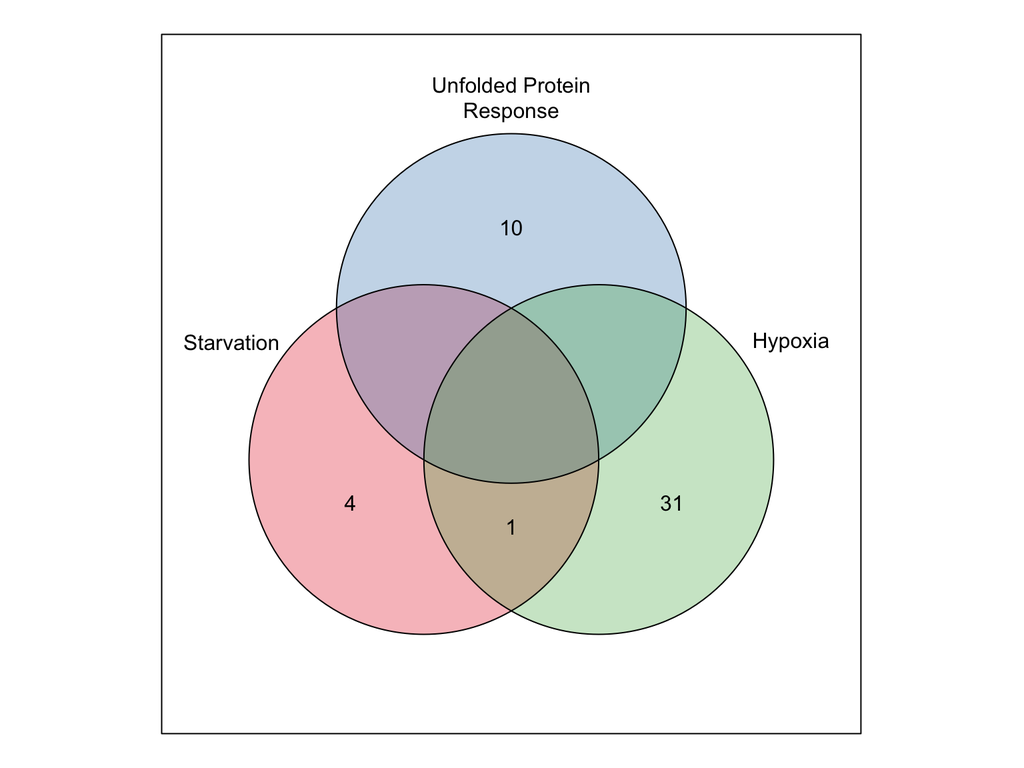

```r
venn::venn(input.v, zcolor = brewer.pal(n = 3, name = "Set1"),
    cexil = 1, cexsn = 1)
```

This brings us to the end of the first part of the analysis which was all about known RBPs and how many of those are involved in the Unfolded Protein Response.

## 02. Cancer Cell Fitness genes

The analysis now focuses on the [paper](https://www.nature.com/articles/s41586-019-1103-9#Sec43) that uses CRISPR screens to identify genes that are required for cancer cell fitness. Based on Supplementary table S2 in this paper, we want to find  
a. The RBPs that are required for cancer cell fitness  
b. Find out how many of these RBPs are involved in stress response pathways – UPR and hypoxia  
c. And how many are RNA modifying enzymes?

### 2a. Cancer fitness genes

We extract metadata information into “metadat” and fitness information into the object “fitness” in the code below. These two dataframes will be used for downstream analysis.

```r
# HT-29 was not classified in the Tissue column so
# did this manually Fitness dataframe
fitness <- read.delim(paste(indir, "Cancer-Fitness-S2.txt",
    sep = "/"), sep = "\t", header = F, stringsAsFactors = F)
dim(fitness)
```

```
## [1] 7474  326
```

```r
colnames(fitness) = fitness[4, ]
rownames(fitness) = fitness$Gene.CellLine

# Metadata
metadat = data.frame(t(fitness[1:4, 2:ncol(fitness)]))
colnames(metadat) = c("Tissue", "Cancer.Type", "CMP.id",
    "Cell.line")

# Resize 'fitness' dataframe and only keep RBP rows
fitness = fitness[5:nrow(fitness), ]
dim(fitness)
```

```
## [1] 7470  326
```

```r
# Reshape
all.fit = reshape2::melt(fitness, id = "Gene.CellLine",
    na.rm = T)
colnames(all.fit) = c("Gene", "Cell.line", "Fitness")
all.fit = left_join(all.fit, metadat)
head(all.fit)
```

|  | Gene | Cell.line | Fitness | Tissue | Cancer.Type | CMP.id |
| --- | --- | --- | --- | --- | --- | --- |
| 1 | A1BG | 22RV1 | 0 | Prostate | Prostate Carcinoma | SIDM00499 |
| 2 | A1CF | 22RV1 | 0 | Prostate | Prostate Carcinoma | SIDM00499 |
| 3 | AAAS | 22RV1 | 0 | Prostate | Prostate Carcinoma | SIDM00499 |
| 4 | AACS | 22RV1 | 0 | Prostate | Prostate Carcinoma | SIDM00499 |
| 5 | AADACL2 | 22RV1 | 0 | Prostate | Prostate Carcinoma | SIDM00499 |
| 6 | AADAT | 22RV1 | 0 | Prostate | Prostate Carcinoma | SIDM00499 |

```r
# Write fitness genes to a text file
write.table(as.data.frame(rownames(fitness)), sep = "\t",
    paste(outdir, "Cancer-fitness-list-for-uniprot.txt",
        sep = "/"), quote = F, row.names = F)
```

### 2b. Cancer fitness and RBP

The most straightforward way of workng out how many fitness genes are RBPs is to merge our list from Section 01 above to the fitness list which is what we do below.

```r
# Add RBP information
all.fit = left_join(all.fit, go.rbp, by = c(Gene = "Gene.name"))
all.fit$is.rbp = TRUE
all.fit$is.rbp[which(is.na(all.fit$Entry))] = FALSE
head(all.fit)
```

|  | Gene | Cell.line | Fitness | Tissue | Cancer.Type | CMP.id | Entry | Entry.name | Protein.names | Organism | Length | Gene.ontology..cellular.component. | Gene.ontology..biological.process. | Gene.ontology..molecular.function. | is.rbp |
| --- | --- | --- | --- | --- | --- | --- | --- | --- | --- | --- | --- | --- | --- | --- | --- |
| 1 | A1BG | 22RV1 | 0 | Prostate | Prostate Carcinoma | SIDM00499 | NA | NA | NA | NA | NA | NA | NA | NA | FALSE |
| 2 | A1CF | 22RV1 | 0 | Prostate | Prostate Carcinoma | SIDM00499 | NA | NA | NA | NA | NA | NA | NA | NA | FALSE |
| 3 | AAAS | 22RV1 | 0 | Prostate | Prostate Carcinoma | SIDM00499 | Q9NRG9 | AAAS_HUMAN | Aladin (Adracalin) | Homo sapiens (Human) | 546 | centrosome [GO:0005813]; cytosol [GO:0005829]; membrane [GO:0016020]; nuclear envelope [GO:0005635]; nuclear membrane [GO:0031965]; nuclear pore [GO:0005643]; nucleoplasm [GO:0005654]; nucleus [GO:000… | fertilization [GO:0009566]; learning [GO:0007612]; mRNA export from nucleus [GO:0006406]; nucleocytoplasmic transport [GO:0006913]; regulation of nucleocytoplasmic transport [GO:0046822]; viral proces… |  | TRUE |
| 4 | AACS | 22RV1 | 0 | Prostate | Prostate Carcinoma | SIDM00499 | NA | NA | NA | NA | NA | NA | NA | NA | FALSE |
| 5 | AADACL2 | 22RV1 | 0 | Prostate | Prostate Carcinoma | SIDM00499 | NA | NA | NA | NA | NA | NA | NA | NA | FALSE |
| 6 | AADAT | 22RV1 | 0 | Prostate | Prostate Carcinoma | SIDM00499 | NA | NA | NA | NA | NA | NA | NA | NA | FALSE |

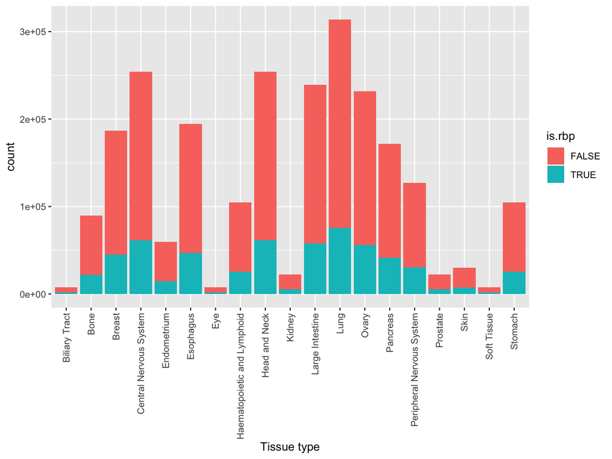

```r
# Plot distribution of RBPs by Tissue
ggplot(all.fit, aes(x = reorder(Tissue, -is.rbp), fill = is.rbp)) +
    geom_bar() + theme(axis.text.x = element_text(angle = 90,
    vjust = 0.5, hjust = 1)) + xlab("Tissue type")
```

Just noting here that given it is the same set of genes that have been queried across all cell-lines and only some of them are RBPs,the proportion of RBPs across all tissues and cell-lines will be identical (24%). The more important question is how many of these are also fitness genes and whether the proportion of “Fitness-RBPs” across cell-lines, tissues and cancer types varies.

## 03. Cancer fitness and RBPs

Our first task is to look at cancer fitness genes that are also known RBPs. We re-use the ‘go.rbp’ dataframe from the previous sections which consist of 2807 currently published RBPs (from interactome capture and OOPS) annotated with GO terms. Furthermore, we want to see if the number of RBPs involved in cancer fitness vary by cancer type or if there is a core set that is crucial to the survival of many cancer types.

### 3a. RBPs by cancer

```r
# Just keep those fitness genes that are also RBPs.
rbp.fitness = fitness[intersect(go.rbp$Gene.name, rownames(fitness)),
    ]

# Reshape data frame
rbp.fit = reshape2::melt(rbp.fitness, id = "Gene.CellLine")
colnames(rbp.fit) = c("Gene", "Cell.line", "Fitness")
rbp.fit = left_join(rbp.fit, metadat)
head(rbp.fit)
```

|  | Gene | Cell.line | Fitness | Tissue | Cancer.Type | CMP.id |
| --- | --- | --- | --- | --- | --- | --- |
| 1 | AHNAK | 22RV1 | 0 | Prostate | Prostate Carcinoma | SIDM00499 |
| 2 | MKI67 | 22RV1 | 0 | Prostate | Prostate Carcinoma | SIDM00499 |
| 3 | LRPPRC | 22RV1 | 0 | Prostate | Prostate Carcinoma | SIDM00499 |
| 4 | PLEC | 22RV1 | 0 | Prostate | Prostate Carcinoma | SIDM00499 |
| 5 | PDCD11 | 22RV1 | 0 | Prostate | Prostate Carcinoma | SIDM00499 |
| 6 | PRPF8 | 22RV1 | 1 | Prostate | Prostate Carcinoma | SIDM00499 |

```r
rbp.fit.t = table(rbp.fit$Cancer.Type, rbp.fit$Fitness)/rowSums(table(rbp.fit$Cancer.Type,
    rbp.fit$Fitness))
melt.t = melt(rbp.fit.t)
colnames(melt.t) = c("Cancer.Type", "Fitness", "Percentage")
melt.t$Fitness = factor(melt.t$Fitness, levels = c(1,
    0))
melt.t$Percentage = round(melt.t$Percentage * 100,
    0)

pdf(paste(plotdir, "RBPs-by-cancer-type-and-fitness.pdf",
    sep = "/"))
p <- ggplot() + geom_bar(aes(y = Percentage, x = Cancer.Type,
    fill = Fitness), data = melt.t, stat = "identity")
p = p + theme_bw() + theme(plot.title = element_text(hjust = 0.5),
    axis.text.x = element_text(angle = 90, hjust = 0.95,
        vjust = 0.2))
p = p + scale_fill_manual(values = c("maroon", "lightblue")) +
    ggtitle("RNA Binding proteins by Cancer Type and Fitness Score")
print(p)
dev.off()
```

```r
# Numbers of cell lines in each cancer type - need
# to normalise for that.
cancer.num = as.data.frame(table(metadat$Cancer.Type))
colnames(cancer.num)[1] = "Cancer.Type"
rbp.fit.num.by.cancer = as.data.frame.matrix(table(rbp.fit$Cancer.Type,
    rbp.fit$Fitness))
av.fit.rbp.per.cancer = round(rbp.fit.num.by.cancer/cancer.num$Freq,
    0)

# Cancer type distribution
pdf(paste(plotdir, "Cell-line-number-by-cancer-type.pdf",
    sep = "/"))
cancer.num = cancer.num[order(cancer.num$Freq, decreasing = T),
    ]
cancer.num$Cancer.Type = factor(cancer.num$Cancer.Type,
    levels = cancer.num$Cancer.Type)
ggplot(data = cancer.num) + geom_bar(aes(x = Cancer.Type,
    y = Freq), stat = "identity", fill = "thistle") +
    theme_bw() + theme(plot.title = element_text(hjust = 0.5),
    axis.text.x = element_text(angle = 90, hjust = 0.95,
        vjust = 0.2)) + ylab("Number of cell lines")
dev.off()
```

While looking at only those genes that are in the known.rbp list and in the Cancer Fitness study, we have an overlap of 1801. On a cancer type level, the range of these RBPs that are involved in core-fitness is between 25 and 45% with the median at 37%. It is useful to note that solid tumours are more highly represented in the dataset than others with colorectal, breast, ovarian, glioblastoma and pancreatic making the top 5.

## 04. Cancer Fitness and the Unfolded Protein Response

Here we want to see how many of the ~7500 cancer fitness genes are related to the unfolded protein response, hypoxia and endoplasmic reticulum as well as the integrated stress reponse. I’m going to do as I did with the RBPs, upload the list to Uniprot and download GO terms followed by filtering.

### 4a. Cancer fitness gene annotation

We have 7470 genes and we are going to try and get the GO terms for all of these. Follow up questions could be - how many UPR genes per cancer ? Is there a particular cancer with a high number of UPR/Hypoxia/Stress

```r
# Annotate Cancer fitness genes with GO terms from
# Uniprot
go.fit = read.delim(paste(indir, "cancer-fitness-uniprot.txt",
    sep = "/"), sep = "\t", stringsAsFactors = F, header = T)
colnames(go.fit)[6] = "Gene.name"

# Hypoxia response
hypox.fit = go.fit[with(go.fit, grepl("GO:0001666",
    paste(Gene.ontology..biological.process., Gene.ontology..cellular.component.,
        Gene.ontology..molecular.function.))), ]

upr.fit = go.fit[with(go.fit, grepl("GO:0030968", paste(Gene.ontology..biological.process.,
    Gene.ontology..cellular.component., Gene.ontology..molecular.function.))),
    ]

starv.fit = go.fit[with(go.fit, grepl("GO:0042594",
    paste(Gene.ontology..biological.process., Gene.ontology..cellular.component.,
        Gene.ontology..molecular.function.))), ]

print(length(upr.fit$Gene.name))
```

```
## [1] 21
```

```r
print(length(hypox.fit$Gene.name))
```

```
## [1] 59
```

```r
print(length(starv.fit$Gene.name))
```

```
## [1] 14
```

```r
# Concatenate genes into a list for output
all.fit.out = rbind(cbind(hypox.fit, Category = "Hypoxia-Cancer-Fitness"),
    cbind(upr.fit, Category = "UPR-Cancer-Fitness"),
    cbind(starv.fit, Category = "Starvation-Cancer-Fitness"))

write.table(all.fit.out, paste(outdir, "UPR-Hypoxia-Starvation-Cancer-Fitness-Genes.txt",
    sep = "/"), sep = "\t", row.names = F, quote = F)

# Write lists of proteins to file
write.table(hypox.fit, paste(outdir, "Hypoxia-Fitness-genes.txt",
    sep = "/"), sep = "\t", row.names = F, quote = F)
write.table(starv.fit, paste(outdir, "Starvation-Fitness-genes.txt",
    sep = "/"), sep = "\t", row.names = F, quote = F)
write.table(upr.fit, paste(outdir, "UPR-Fitness-genes.txt",
    sep = "/"), sep = "\t", row.names = F, quote = F)

# Plot intersect
input.v.fit = list(Starvation = starv.fit$Gene.name,
    `Unfolded Protein\nResponse` = upr.fit$Gene.name,
    Hypoxia = hypox.fit$Gene.name)
pdf(paste(plotdir, "UPR-Hypoxia-ER-Cancer-fitness-genes-Venn.pdf",
    sep = "/"))
v = venn::venn(input.v.fit, zcolor = brewer.pal(n = 4,
    name = "Set1"), cexil = 1, cexsn = 1, main = "Cancer Fitness Genes & the Integrated Stress Response")
dev.off()
```

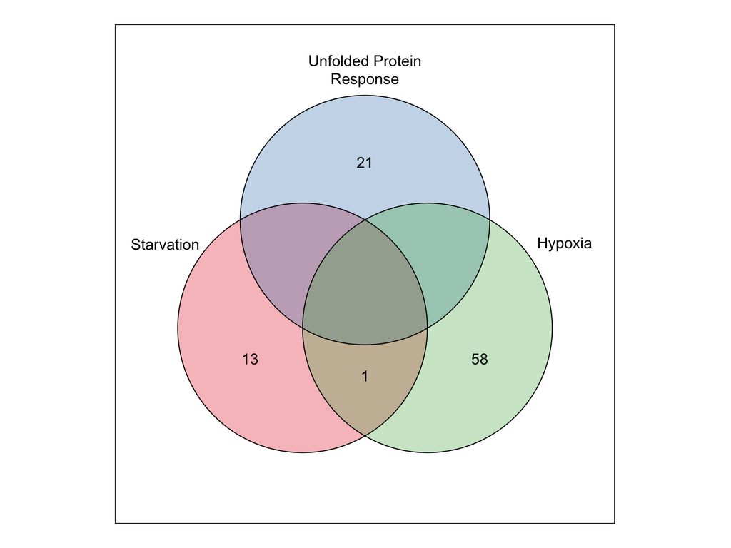

```r
venn::venn(input.v.fit, zcolor = brewer.pal(n = 3,
    name = "Set1"), cexil = 1, cexsn = 1, main = "Cancer Fitness Genes & the Integrated Stress Response")
```

### 4b. Cancer fitness genes that relate to Hypoxia

Here, we are looking at cancer fitness genes that are also known to play a role in hypoxia and if that list differs across cancer types.

```r
# Isolate hypoxia related cancer fitness genes and
# see if they occur in a particular cancer type
# hypox.fit$Gene.name
hypox.fitness = fitness[hypox.fit$Gene.name, ]

# Reshape data frame
hypox.fitness.melt = reshape2::melt(hypox.fitness,
    id = "Gene.CellLine", na.rm = T)
colnames(hypox.fitness.melt) = c("Gene", "Cell.line",
    "Fitness")
hypox.fitness.melt = left_join(hypox.fitness.melt,
    metadat)
# head(hypox.fitness.melt)

# Fitness only hypoxia genes
fit.hypox.1 = hypox.fitness.melt[which(hypox.fitness.melt$Fitness ==
    1), ]
p <- ggplot(fit.hypox.1, aes(y = Gene, x = Cancer.Type)) +
    geom_tile(aes(fill = Fitness)) + theme_bw() + theme(plot.title = element_text(hjust = 0.5),
    axis.text.x = element_text(angle = 90, hjust = 0.95,
        vjust = 0.2), axis.text.y = element_text(size = 6),
    legend.title = element_blank(), legend.position = "none")

# Plot the heatmap of genes
p
pdf(paste(plotdir, "Hypoxia-heatmap.pdf", sep = "/"))
print(p)
dev.off()
```

```r
# Create a data table showing number of hypoxia
# fitness genes by cancer
dt = data.frame(table(fit.hypox.1$Cancer.Type))
colnames(dt) = c("Cancer.Type", "Hypoxia.Genes")
dt = left_join(dt, cancer.num)
colnames(dt)[3] = "Cell.Lines"
dt$Av.Hypoxia = ceiling(dt$Hypoxia.Genes/dt$Cell.Lines)
dt = dt[order(dt$Av.Hypoxia, decreasing = T), ]
dt
```

|  | Cancer.Type | Hypoxia.Genes | Cell.Lines | Av.Hypoxia |
| --- | --- | --- | --- | --- |
| 1 | Acute Myeloid Leukemia | 25 | 2 | 13 |
| 2 | B Cell Non Hodgkin`s Lymphoma | 51 | 5 | 11 |
| 29 | Plasma Cell Myeloma | 53 | 5 | 11 |
| 25 | Other Endometrial Cancers | 10 | 1 | 10 |
| 31 | Soft Tissue Carcinomas | 10 | 1 | 10 |
| 4 | Blood Non Cancerous | 17 | 2 | 9 |
| 12 | Gastric Carcinoma | 114 | 14 | 9 |
| 18 | Melanoma | 36 | 4 | 9 |
| 32 | Squamous Cell Lung Carcinoma | 89 | 11 | 9 |
| 6 | Colorectal Carcinoma | 235 | 32 | 8 |

[output cut: 22 more lines]

```r
# Of all hypoxia genes, what percentage are fitness
# related by cancer-type (i.e Fitness = 1)
hypox.tab = round(100 * table(hypox.fitness.melt$Cancer.Type,
    hypox.fitness.melt$Fitness)/rowSums(table(hypox.fitness.melt$Cancer.Type,
    hypox.fitness.melt$Fitness)), 0)
hypox.tab = hypox.tab[order(hypox.tab[, 2], decreasing = T),
    ]
# hypox.tab
```

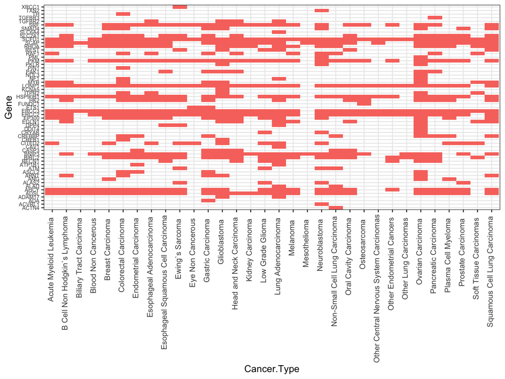

### 4c. Cancer fitness genes that relate to Unfolded Protein Response

Here, we are looking at cancer fitness genes that are also known to play a role in Unfolded Protein response and if that list differs across cancer types.

```r
# Isolate UPR related cancer fitness genes and see
# if they occur in a particular cancer type
# upr.fit$Gene.name
upr.fitness = fitness[upr.fit$Gene.name, ]

# Reshape data frame
upr.fitness.melt = reshape2::melt(upr.fitness, id = "Gene.CellLine",
    na.rm = T)
colnames(upr.fitness.melt) = c("Gene", "Cell.line",
    "Fitness")
upr.fitness.melt = left_join(upr.fitness.melt, metadat)
# head(upr.fitness.melt)

# Fitness only UPR genes
fit.upr.1 = upr.fitness.melt[which(upr.fitness.melt$Fitness ==
    1), ]
q <- ggplot(fit.upr.1, aes(y = Gene, x = Cancer.Type)) +
    geom_tile(aes(fill = Fitness)) + theme_bw() + theme(plot.title = element_text(hjust = 0.5),
    axis.text.x = element_text(angle = 90, hjust = 0.95,
        vjust = 0.2), axis.text.y = element_text(size = 8),
    legend.title = element_blank(), legend.position = "none")

# Heatmap
q
pdf(paste(plotdir, "UPR-heatmap.pdf", sep = "/"))
print(q)
dev.off()
```

```r
# Create a data table showing number of UPR fitness
# genes by cancer
dt = data.frame(table(fit.upr.1$Cancer.Type))
colnames(dt) = c("Cancer.Type", "UPR.Genes")
dt = left_join(dt, cancer.num)
colnames(dt)[3] = "Cell.Lines"
dt$Av.UPR = ceiling(dt$UPR.Genes/dt$Cell.Lines)
dt = dt[order(dt$Av.UPR, decreasing = T), ]
dt
```

|  | Cancer.Type | UPR.Genes | Cell.Lines | Av.UPR |
| --- | --- | --- | --- | --- |
| 25 | Other Endometrial Cancers | 6 | 1 | 6 |
| 31 | Soft Tissue Carcinomas | 6 | 1 | 6 |
| 9 | Esophageal Squamous Cell Carcinoma | 80 | 19 | 5 |
| 10 | Ewing`s Sarcoma | 41 | 10 | 5 |
| 15 | Kidney Carcinoma | 13 | 3 | 5 |
| 16 | Low Grade Glioma | 41 | 9 | 5 |
| 17 | Lung Adenocarcinoma | 85 | 20 | 5 |
| 19 | Mesothelioma | 5 | 1 | 5 |
| 28 | Pancreatic Carcinoma | 93 | 23 | 5 |
| 3 | Biliary Tract Carcinoma | 4 | 1 | 4 |

[output cut: 22 more lines]

```r
# Of all UPR genes, what percentage are fitness
# related by cancer-type (i.e Fitness = 1)
upr.tab = round(100 * table(upr.fitness.melt$Cancer.Type,
    upr.fitness.melt$Fitness)/rowSums(table(upr.fitness.melt$Cancer.Type,
    upr.fitness.melt$Fitness)), 0)
upr.tab = upr.tab[order(upr.tab[, 2], decreasing = T),
    ]
# upr.tab
```

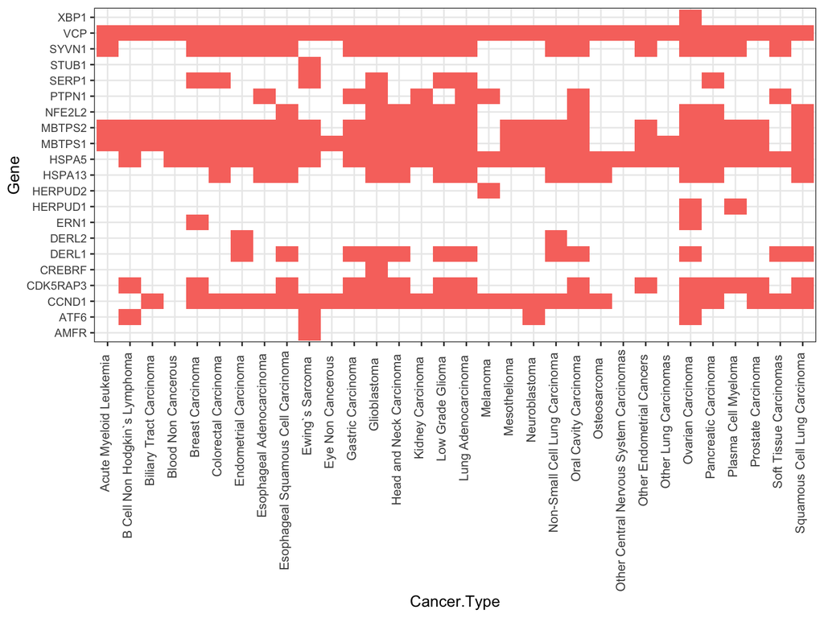

### 4d. Cancer fitness genes that relate to Starvation

Here, we are looking at cancer fitness genes that are also known to play a role in Starvation response in a cell and if that list differs across cancer types.

```r
# Isolate starvation response related cancer
# fitness genes and see if they occur in a
# particular cancer type starv.fit$Gene.name
starv.fitness = fitness[starv.fit$Gene.name, ]

# Reshape data frame
starv.fitness.melt = reshape2::melt(starv.fitness,
    id = "Gene.CellLine", na.rm = T)
colnames(starv.fitness.melt) = c("Gene", "Cell.line",
    "Fitness")
starv.fitness.melt = left_join(starv.fitness.melt,
    metadat)
# head(starv.fitness.melt)

# Fitness only starvation genes
fit.starv.1 = starv.fitness.melt[which(starv.fitness.melt$Fitness ==
    1), ]
r <- ggplot(fit.starv.1, aes(y = Gene, x = Cancer.Type)) +
    geom_tile(aes(fill = Fitness)) + theme_bw() + theme(plot.title = element_text(hjust = 0.5),
    axis.text.x = element_text(angle = 90, hjust = 0.95,
        vjust = 0.2), axis.text.y = element_text(size = 8),
    legend.title = element_blank(), legend.position = "none")

# Heatmap
r
pdf(paste(plotdir, "Starv-heatmap.pdf", sep = "/"))
print(r)
dev.off()
```

```r
# Create a data table showing number of starvation
# fitness genes by cancer
dt = data.frame(table(fit.starv.1$Cancer.Type))
colnames(dt) = c("Cancer.Type", "Starv.Genes")
dt = left_join(dt, cancer.num)
colnames(dt)[3] = "Cell.Lines"
dt$Av.UPR = ceiling(dt$Starv.Genes/dt$Cell.Lines)
dt = dt[order(dt$Av.UPR, decreasing = T), ]
dt
```

|  | Cancer.Type | Starv.Genes | Cell.Lines | Av.UPR |
| --- | --- | --- | --- | --- |
| 3 | Biliary Tract Carcinoma | 4 | 1 | 4 |
| 1 | Acute Myeloid Leukemia | 6 | 2 | 3 |
| 2 | B Cell Non Hodgkin`s Lymphoma | 12 | 5 | 3 |
| 4 | Blood Non Cancerous | 6 | 2 | 3 |
| 29 | Plasma Cell Myeloma | 13 | 5 | 3 |
| 5 | Breast Carcinoma | 34 | 25 | 2 |
| 6 | Colorectal Carcinoma | 50 | 32 | 2 |
| 8 | Esophageal Adenocarcinoma | 12 | 7 | 2 |
| 12 | Gastric Carcinoma | 22 | 14 | 2 |
| 17 | Lung Adenocarcinoma | 23 | 20 | 2 |

[output cut: 22 more lines]

```r
# Of all Starvation genes, what percentage are
# fitness related by cancer-type (i.e Fitness = 1)
starv.tab = round(100 * table(starv.fitness.melt$Cancer.Type,
    starv.fitness.melt$Fitness)/rowSums(table(starv.fitness.melt$Cancer.Type,
    starv.fitness.melt$Fitness)), 0)
starv.tab = starv.tab[order(starv.tab[, 2], decreasing = T),
    ]
# starv.tab
```

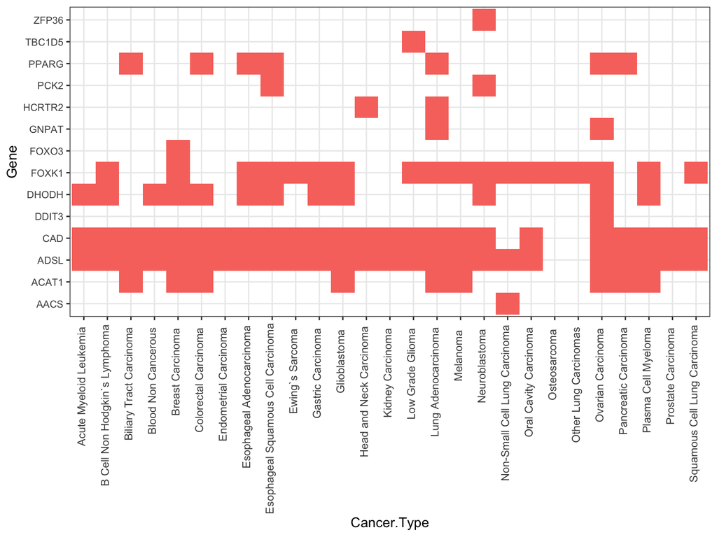